# Project: Investigate (Medical Appointment No Shows) Dataset

- Introduction
- Data Wrangling
- Exploratory Data Analysis
- Conclusions

## Introduction

### Dataset Discription:

> This dataset collects information from 100k medical appointments in Brazil and is focused on the question of whether or not patients show up for their appointment. A number of characteristics about the patient are included in each row.

### Dataset Dictionary:

| Column | Description |
| --- | --- |
| PatientId | Identification of a patient |
| AppointmentID | dentification of each appointment |
| Gender | Male or Female . Female is the greater proportion, woman takes way more care of they health in comparison to man. |
| DataMarcacaoConsulta | The day of the actuall appointment, when they have to visit the doctor. |
| DataAgendamento | The day someone called or registered the appointment, this is before appointment of course. |
| Age | How old is the patient. |
| Neighbourhood | indicates the location of the hospital, Where the appointment takes place. |
| Scholarship | indicates whether or not the patient is enrolled in Brasilian welfare program [Bolsa Família.](https://en.wikipedia.org/wiki/Bolsa_Fam%C3%ADlia) |
| Hipertension | indicates whether or not the patient is experiencing Hypertension. True or False |
| Diabetes | indicates whether or not the patient is experiencing Diabetes. True or False |
| Alcoholism | indicates whether or not the patient is experiencing Alcoholism. True or False |
| Handcap | indicates whether or not the patient is with special needs. True or False |
| SMS_received | indicates whether or not the patient has received a reminder text message. 1 or more messages sent to the patient. |
| No-show | ‘No’ if the patient showed up to their appointment, and ‘Yes’ if they did not show up. |

## Questions we are trying to answer :

Q1- what is the overall appointment show-up and no show-up rate?

Q2- what are the most feature that affect to No_show?

## Description of the analysis

first i will find percentage of showed patients and i will find the relations between No_show column and other columns to find Highest Impact Column

note that i will not use (PatientId, AppointmentID, ScheduledDay, AppointmentDay) columns at this analyse but i will check them

```python
#import important Libraries
import numpy as np
import pandas as pd
import matplotlib.pyplot as plt
import seaborn as sns

%matplotlib inline
```

## Data Wrangling

### General Properties

```python
# loading the dataset
df = pd.read_csv('noshowappointments-kagglev2-may-2016.csv')
```

### Checking Data

```python
df.head()
```

|  | PatientId | AppointmentID | Gender | ScheduledDay | AppointmentDay | Age | Neighbourhood | Scholarship | Hipertension | Diabetes | Alcoholism | Handcap | SMS_received | No-show |
| --- | --- | --- | --- | --- | --- | --- | --- | --- | --- | --- | --- | --- | --- | --- |
| 0 | 2.987250e+13 | 5642903 | F | 2016-04-29T18:38:08Z | 2016-04-29T00:00:00Z | 62 | JARDIM DA PENHA | 0 | 1 | 0 | 0 | 0 | 0 | No |
| 1 | 5.589978e+14 | 5642503 | M | 2016-04-29T16:08:27Z | 2016-04-29T00:00:00Z | 56 | JARDIM DA PENHA | 0 | 0 | 0 | 0 | 0 | 0 | No |
| 2 | 4.262962e+12 | 5642549 | F | 2016-04-29T16:19:04Z | 2016-04-29T00:00:00Z | 62 | MATA DA PRAIA | 0 | 0 | 0 | 0 | 0 | 0 | No |
| 3 | 8.679512e+11 | 5642828 | F | 2016-04-29T17:29:31Z | 2016-04-29T00:00:00Z | 8 | PONTAL DE CAMBURI | 0 | 0 | 0 | 0 | 0 | 0 | No |
| 4 | 8.841186e+12 | 5642494 | F | 2016-04-29T16:07:23Z | 2016-04-29T00:00:00Z | 56 | JARDIM DA PENHA | 0 | 1 | 1 | 0 | 0 | 0 | No |

```python
df.describe()
```

|  | PatientId | AppointmentID | Age | Scholarship | Hipertension | Diabetes | Alcoholism | Handcap | SMS_received |
| --- | --- | --- | --- | --- | --- | --- | --- | --- | --- |
| count | 1.105270e+05 | 1.105270e+05 | 110527.000000 | 110527.000000 | 110527.000000 | 110527.000000 | 110527.000000 | 110527.000000 | 110527.000000 |
| mean | 1.474963e+14 | 5.675305e+06 | 37.088874 | 0.098266 | 0.197246 | 0.071865 | 0.030400 | 0.022248 | 0.321026 |
| std | 2.560949e+14 | 7.129575e+04 | 23.110205 | 0.297675 | 0.397921 | 0.258265 | 0.171686 | 0.161543 | 0.466873 |
| min | 3.921784e+04 | 5.030230e+06 | -1.000000 | 0.000000 | 0.000000 | 0.000000 | 0.000000 | 0.000000 | 0.000000 |
| 25% | 4.172614e+12 | 5.640286e+06 | 18.000000 | 0.000000 | 0.000000 | 0.000000 | 0.000000 | 0.000000 | 0.000000 |
| 50% | 3.173184e+13 | 5.680573e+06 | 37.000000 | 0.000000 | 0.000000 | 0.000000 | 0.000000 | 0.000000 | 0.000000 |
| 75% | 9.439172e+13 | 5.725524e+06 | 55.000000 | 0.000000 | 0.000000 | 0.000000 | 0.000000 | 0.000000 | 1.000000 |
| max | 9.999816e+14 | 5.790484e+06 | 115.000000 | 1.000000 | 1.000000 | 1.000000 | 1.000000 | 4.000000 | 1.000000 |

```python
df.info()
```

```
<class 'pandas.core.frame.DataFrame'>
RangeIndex: 110527 entries, 0 to 110526
Data columns (total 14 columns):
 #   Column          Non-Null Count   Dtype
---  ------          --------------   -----
 0   PatientId       110527 non-null  float64
 1   AppointmentID   110527 non-null  int64
 2   Gender          110527 non-null  object
 3   ScheduledDay    110527 non-null  object
 4   AppointmentDay  110527 non-null  object
 5   Age             110527 non-null  int64
 6   Neighbourhood   110527 non-null  object
 7   Scholarship     110527 non-null  int64
 8   Hipertension    110527 non-null  int64
 9   Diabetes        110527 non-null  int64
 10  Alcoholism      110527 non-null  int64
 11  Handcap         110527 non-null  int64
 12  SMS_received    110527 non-null  int64
 13  No-show         110527 non-null  object
dtypes: float64(1), int64(8), object(5)
memory usage: 11.8+ MB
```

The ouput shows that there are 110,527 rows divided to 14 columns.

no null fields.

it seems that the data set has two columns with incorrect data types

- ScheduledDay
- AppointmentDay

no-show column need to rename

```python
#check duplicates
df.duplicated().sum()
```

```
0
```

```python
#check uniques
df.nunique()
```

```
PatientId          62299
AppointmentID     110527
Gender                 2
ScheduledDay      103549
AppointmentDay        27
Age                  104
Neighbourhood         81
Scholarship            2
Hipertension           2
Diabetes               2
Alcoholism             2
Handcap                5
SMS_received           2
No-show                2
dtype: int64
```

interesting lets check (PatientId, AppointmentID)

```python
df.loc[:, ['PatientId', 'AppointmentID']].nunique()
```

```
PatientId         62299
AppointmentID    110527
dtype: int64
```

we see all AppointmentID are unique values but there are much repetition at PatientId, but i won't use them just check

```python
#check age values
df.Age.value_counts()
```

```
 0      3539
 1      2273
 52     1746
 49     1652
 53     1651
        ...
 115       5
 100       4
 102       2
 99        1
-1         1
Name: Age, Length: 104, dtype: int64
```

There is just 1 value = -1 : I will drop it.

```python
#Check Neighbourhood
df.Neighbourhood.value_counts()
```

```
JARDIM CAMBURI                 7717
MARIA ORTIZ                    5805
RESISTÊNCIA                    4431
JARDIM DA PENHA                3877
ITARARÉ                        3514
                               ...
ILHA DO BOI                      35
ILHA DO FRADE                    10
AEROPORTO                         8
ILHAS OCEÂNICAS DE TRINDADE       2
PARQUE INDUSTRIAL                 1
Name: Neighbourhood, Length: 81, dtype: int64
```

## Data Cleaning

```python
# drop two columns (PatientId,AppointmentID)
df.drop(labels=['PatientId', 'AppointmentID'], axis=1, inplace=True)
df.head(1)
```

|  | Gender | ScheduledDay | AppointmentDay | Age | Neighbourhood | Scholarship | Hipertension | Diabetes | Alcoholism | Handcap | SMS_received | No-show |
| --- | --- | --- | --- | --- | --- | --- | --- | --- | --- | --- | --- | --- |
| 0 | F | 2016-04-29T18:38:08Z | 2016-04-29T00:00:00Z | 62 | JARDIM DA PENHA | 0 | 1 | 0 | 0 | 0 | 0 | No |

```python
# Convert ScheduledDay to datetime type
df.ScheduledDay = pd.to_datetime(df.ScheduledDay)
df.ScheduledDay.head(1)
```

```
0   2016-04-29 18:38:08+00:00
Name: ScheduledDay, dtype: datetime64[ns, UTC]
```

```python
# Convert ppointmentDay to datetime type
df.AppointmentDay = pd.to_datetime(df.AppointmentDay)
df.AppointmentDay.head(1)
```

```
0   2016-04-29 00:00:00+00:00
Name: AppointmentDay, dtype: datetime64[ns, UTC]
```

```python
#rename No-show columns
df.rename(columns= {'No-show':'No_show'}, inplace=True)
df.head(1)
```

[output not shown]

```python
#Drop age row contains a negative value
df.drop(df.query("Age == -1").index,inplace=True)
df.Age.describe()
```

```
count    110526.000000
mean         37.089219
std          23.110026
min           0.000000
25%          18.000000
50%          37.000000
75%          55.000000
max         115.000000
Name: Age, dtype: float64
```

## Exploration of the dataset

```python
# function to find line chart plot figure
def line_plot(col):
    df[col].dt.date.value_counts().plot(kind="line",figsize=(10,4))
    plt.ylabel("Count")
    plt.title(col +" "+"Line chart")
```

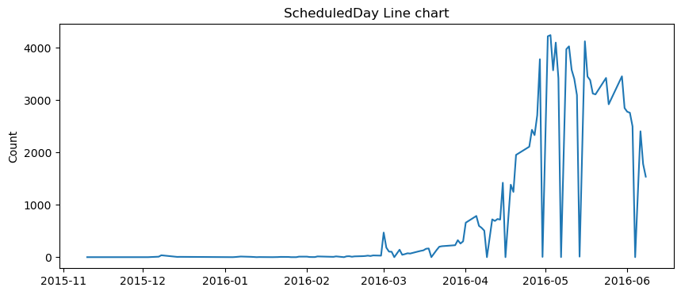

```python
# line chart plot for 'ScheduledDay'
line_plot("ScheduledDay")
```

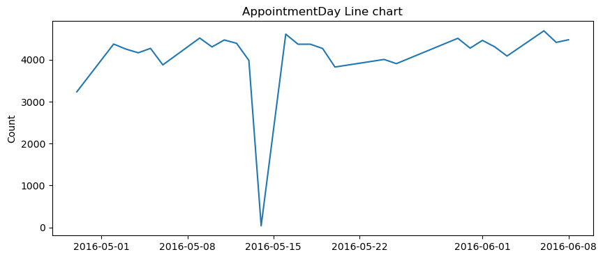

```python
# line chart plot for 'AppointmentDay'
line_plot("AppointmentDay")
```

we can extract day from AppointmentDay and check has affect or not

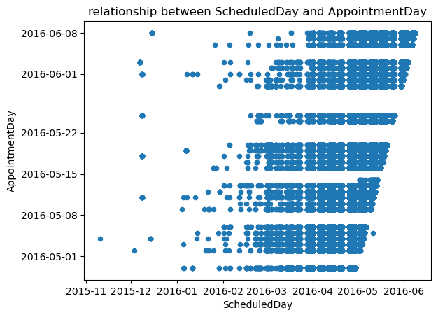

```python
# Scatter plot for the relationship between ScheduledDay and AppointmentDay
df.plot(kind="scatter", x="ScheduledDay",y="AppointmentDay");
plt.title("relationship between ScheduledDay and AppointmentDay");
```

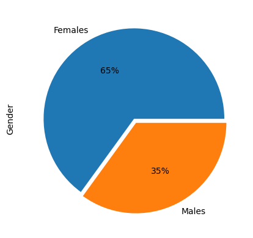

```python
# female : male %
df["Gender"].value_counts().plot(kind="pie",labels=["Females","Males"], autopct='%1.0f%%', explode=(0, .05));
```

65% of patients are females

Most patient are females

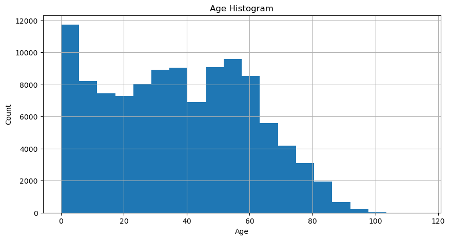

```python
# Histogram plot of Age
df.Age.hist(bins=20,figsize=(10,5))
plt.xlabel("Age")
plt.ylabel("Count")
plt.title("Age Histogram");
```

Most of patients between 20:60

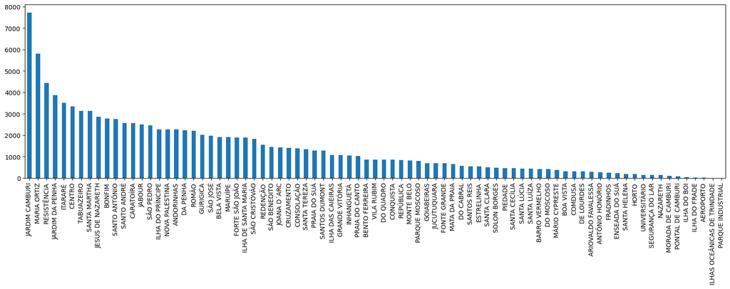

```python
df.Neighbourhood.value_counts().plot(kind="bar",figsize=(20,5));
```

jardim cambburi have the highest appointment and parque industrial the opposite and there is no information to explore why

```python
# function to find bar plot
def bar_plot(col):
    df[col].value_counts().plot(kind="bar")
    plt.xlabel(col)
    plt.ylabel("Count")
    plt.title(col+" "+"Plot");
```

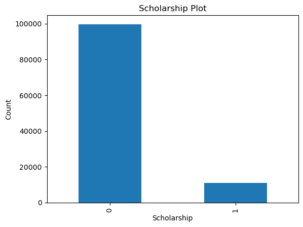

```python
# bar plot of Scholarship
bar_plot("Scholarship")
```

most of patients didn't have scholarship

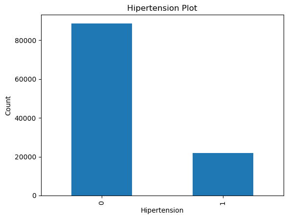

```python
# bar plot of Hipertension
bar_plot("Hipertension")
```

most of patients didn't experiencing Hipertension

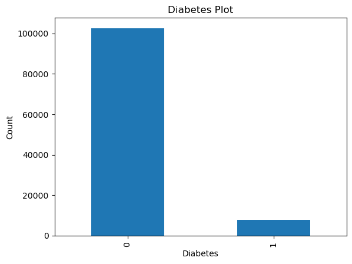

```python
# bar plot of Diabetes
bar_plot("Diabetes")
```

most of patients didn't experiencing Diabetes

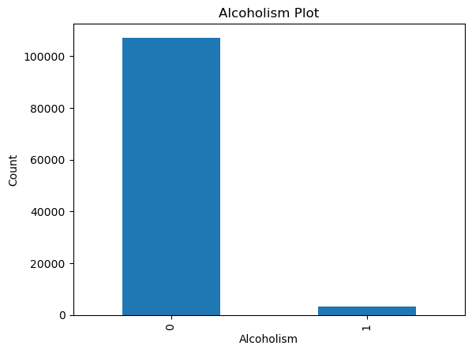

```python
# bar plot of Alcoholism
bar_plot("Alcoholism")
```

most of patients didn't experiencing alcoholism

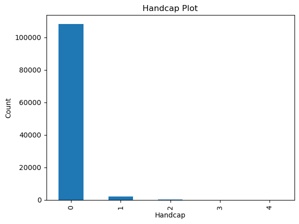

```python
# bar plot of Handcap
bar_plot("Handcap")
```

most of patients didn't experiencing Handcap

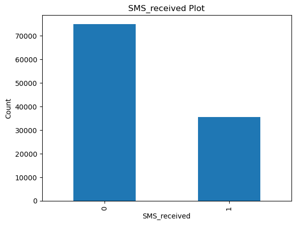

```python
# bar plot of SMS_received
bar_plot("SMS_received")
```

most of patients didn't receive sms

## General Exploration Results

- The proportion of females is greater than that of males.
- The Age range is contain nearly all ages (from 0 to 115) and the majority is in very young age and between 20 and 55.
- There is 81 neighbourhood where the appointment takes place.
- Most of the patients have No : Scholarship , Hipertension, Diabetes , Alcoholism, Handcap
- 20% of patient missed their appointment.

## Exploratory Data Analysis

After explore Data let's answer two Questions i found interesting

The main goal is to find what factor has the most affect to number of shows so i will figure the relation between showed patients and factors

### Q1 what is the overall appointment show-up and no show-up rate??

```python
# making masks to use later
miss = df["No_show"] == "Yes"
show = df["No_show"] == "No"
df['show'] = show
df['miss'] = miss
```

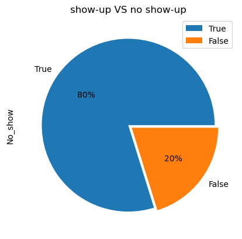

```python
show.value_counts().plot(kind="pie", autopct='%1.0f%%', explode=(0, .05))
plt.title('show-up VS no show-up')
plt.legend();
```

From result 20% from patients didn't show up

### Q2: what are the most feature that affect to No_show?

```python
# compare between patients who showed and who didn't based on age factor
df.Age[show].mean(),df.Age[miss].mean()
```

```
(37.790064393252315, 34.31766656212196)
```

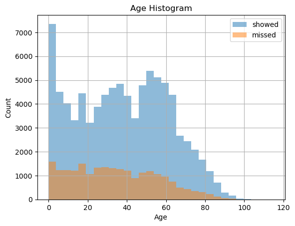

```python
# histogram for ages of patients
df[show].Age.hist(alpha=0.5, bins=30,label="showed")
df[miss].Age.hist(alpha=0.5, bins=30,label="missed")
plt.legend();
plt.title("Age Histogram")
plt.xlabel("Age")
plt.ylabel("Count");
```

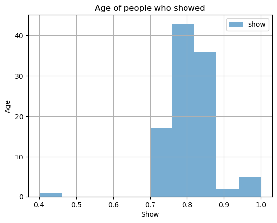

```python
df.groupby('Age')['show'].mean().hist(alpha=0.6,label='show')
plt.xlabel("Show")
plt.ylabel("Age")
plt.title("Age of people who showed")
plt.legend();
```

```python
# function to find the mean and barplot figure
def mean_and_barplot(col):
    print(df.groupby(col)['show'].mean())
    df.groupby(col)['show'].mean().plot(kind='bar',figsize=(22,10));
    plt.xlabel("Show")
    plt.ylabel(col)
    plt.title("relation between"+" "+col+" "+"and patients who showed")
    plt.legend();
```

all figures below will tell us that if (Hipertension, Handcap, Diabetes, Neighbourhood, Scholarship, SMS_received, Alcoholism and Gender ) taken into account if we want to know the patient will appear at his appointment or not

```
Gender
F    0.796854
M    0.800321
Name: show, dtype: float64
```

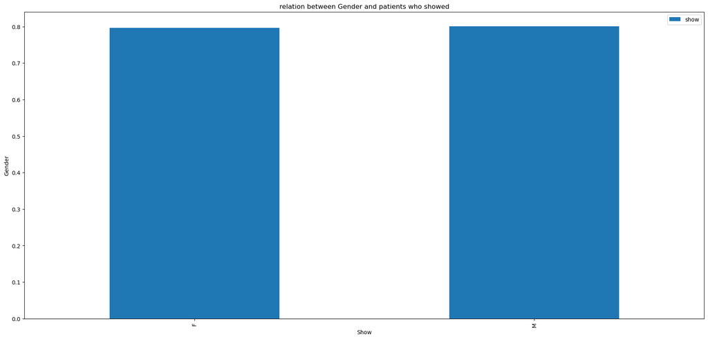

```python
mean_and_barplot("Gender")
```

from result the Gender didn't affect at the number of show as you can see form mean result and figure

```
Alcoholism
0    0.798054
1    0.798512
Name: show, dtype: float64
```

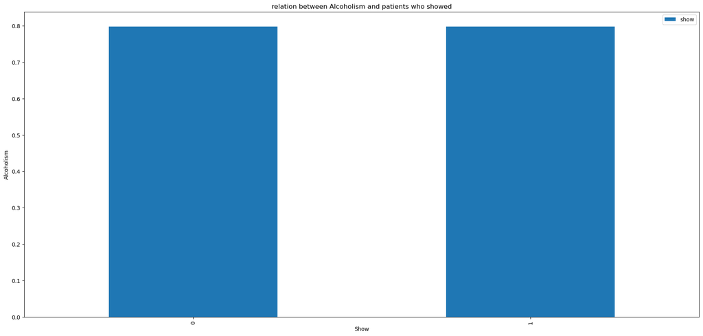

```python
mean_and_barplot("Alcoholism")
```

```
SMS_received
0    0.832967
1    0.724255
Name: show, dtype: float64
```

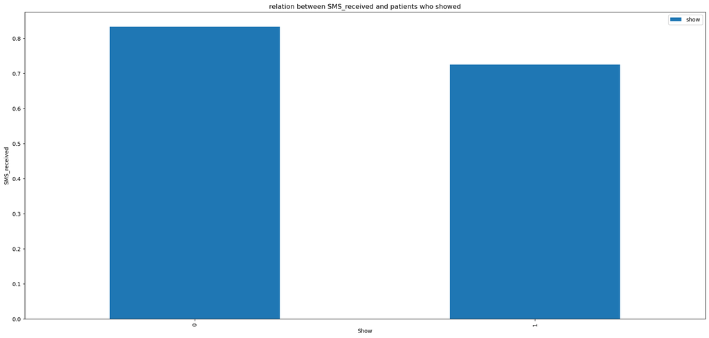

```python
mean_and_barplot("SMS_received")
```

```
Scholarship
0    0.801928
1    0.762637
Name: show, dtype: float64
```

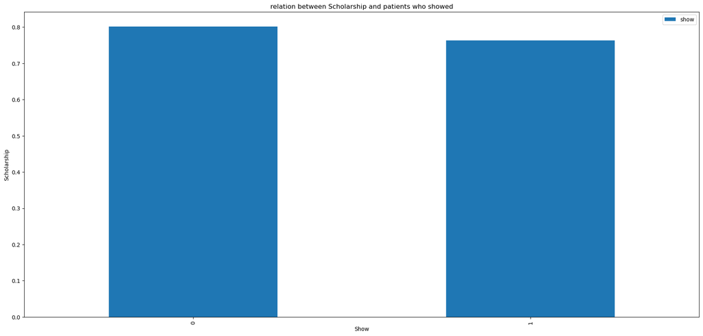

```python
mean_and_barplot("Scholarship")
```

```
Neighbourhood
AEROPORTO              0.875000
ANDORINHAS             0.769673
ANTÔNIO HONÓRIO        0.815498
ARIOVALDO FAVALESSA    0.780142
BARRO VERMELHO         0.784870
                         ...
SÃO JOSÉ               0.783510
SÃO PEDRO              0.789624
TABUAZEIRO             0.817050
UNIVERSITÁRIO          0.789474
VILA RUBIM             0.834313
Name: show, Length: 81, dtype: float64
```

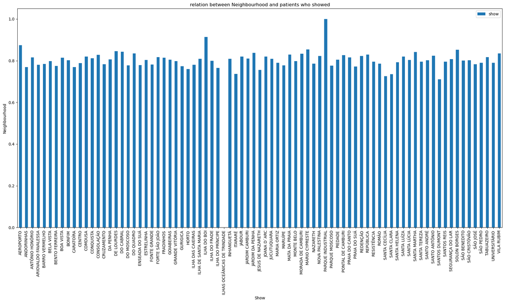

```python
mean_and_barplot("Neighbourhood")
```

```
Diabetes
0    0.796372
1    0.819967
Name: show, dtype: float64
```

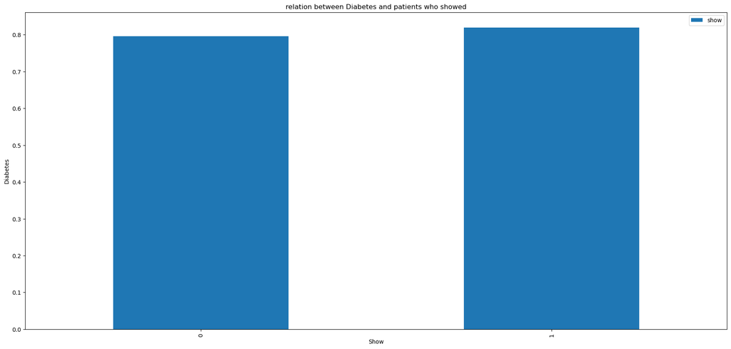

```python
mean_and_barplot("Diabetes")
```

```
Handcap
0    0.797647
1    0.820764
2    0.797814
3    0.769231
4    0.666667
Name: show, dtype: float64
```

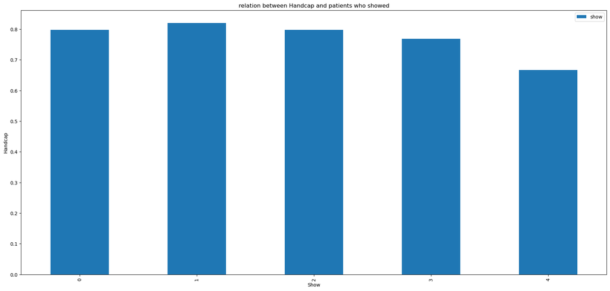

```python
mean_and_barplot("Handcap")
```

```
Hipertension
0    0.790963
1    0.826980
Name: show, dtype: float64
```

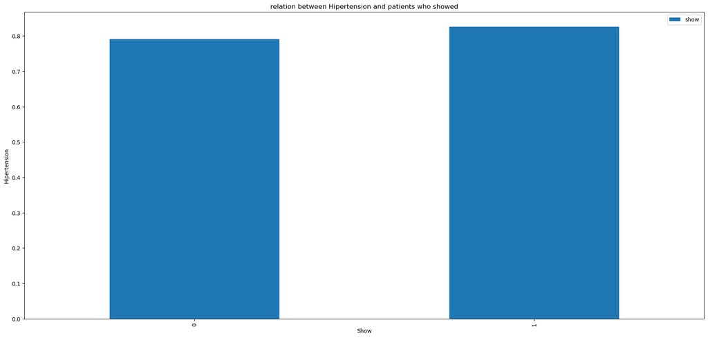

```python
mean_and_barplot("Hipertension")
```

## limitations

- There was no explanation of how the data was collected, and if it was collected in a way that makes these analyses more reliable.
- The Handcap and SMS_received columns weren't explained clearly on the dataset page.
- The dataset didn't explain why the patient comes to the doctor, which may give an additional explanation about why they miss their appointments.
- The PatientId column was little bit confusing

## references:

- [stackoverflow](https://stackoverflow.com/)
- [pandas documentation](https://pandas.pydata.org/pandas-docs/stable/index.html)
- [kaggle](https://www.kaggle.com/)